# Assignment1_perceptron and activation function

### Deep Learning - Dr. Xingquan (Hill) Zhu

### Assignment 1

### Hsin Ting Ho (Z#23500922)

#### Question 1 [2pts: 0.4/each]:

#### Use your own language to briefly explain following concepts:

##### 1) Machine learning:

> Machine learning is a problem soving approach that improve itself by analyzing training examples. Machine learning can complete tasks such as classification and numeric prediction without being explicitly programmed because algorithms enable self-learning. There are three main learning types, supervised learning, unsupervised learning, and reinforcement learning.

##### 2)Machine learning models:

> Machine learning models are the outputs of machine learning algorithms that are capable of , including but not limited to, classifying and forcasting. Machine learning models are produced by feeding data to machine learning algorithms.

##### 3)Neural Network:

> Neural network is a machine learning technique. A neural network is constructed by one or more layers of artificial neurons, whichs are a series of algorithms.

##### 4)Key difference between Rule-based systems, Classic machine learing, and Deep learning:

> Rule-based systems reply on predefined rules or patterns to make prediction or classification.

> Classic machine learing relies on training data with redefined features (and feature values) to learn classification or prediction models.

> Deep learning learns features (or feature representation) from the input data using multiple layers of neural networks.

##### 5)Artificial Neuron

> An artificial neuron is a mathmatical function that produce an output by permform caculation with the inputs and their weights. It is the most basic element of a neural network.

#### Question 2[1pts]

#### Show perceptron structure and explain the function of each component, including inputs, weights, summing function, activation function, and output [1pt].

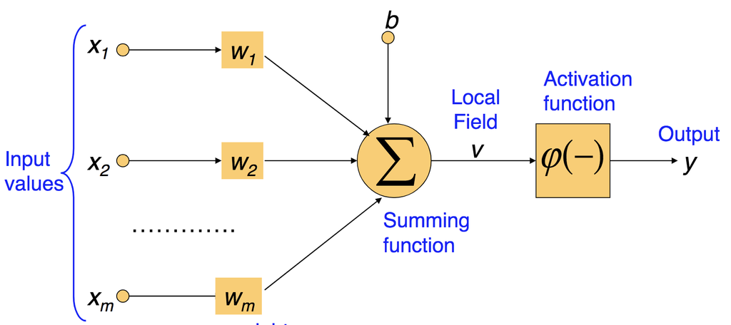

#### 1. Inputs(X1, X2, ..., Xm)

> inputs are numerical values that feed into a neuron

#### 2. b

> b is bias which is always set to 1. Bias is adjusted with a weight before feed into summing function.

#### 3. weights(W1, W2, ..., Wm)

> weights are used to emphasize or to play down input values to achive a more desirable output

#### 4. summing function

> summing funciton sum all the products of input and its weight

#### 5. activation function

> activation function is an equation that transform the result of the summing function to an output.

#### 6. output

> output is produced by all above calculation. It can be the final result of a network or the input of another neuron

#### Question 3 [1.5pt].

#### Given a set of images, please design a network (with one hidden layers) to classify images into three categories: cat, dog, others. Show network architecture, including inputs, neurons and outputs[0. 5 pt]

[figure not shown]

#### What is the purpose of using training examples in a neural network[0.5 pt]?

> Training examples are served as teaching materials for neurons. Neurons learn from the traning example to derive desired pattern within data.

#### what is expected output vs. actual output of each neuron, with respect to a training sample? [0.5pt]

> Expected output is the label of the training sample, and the actual output is the output produced by the neural network with the given traning sample.

#### Question 4[1pt]

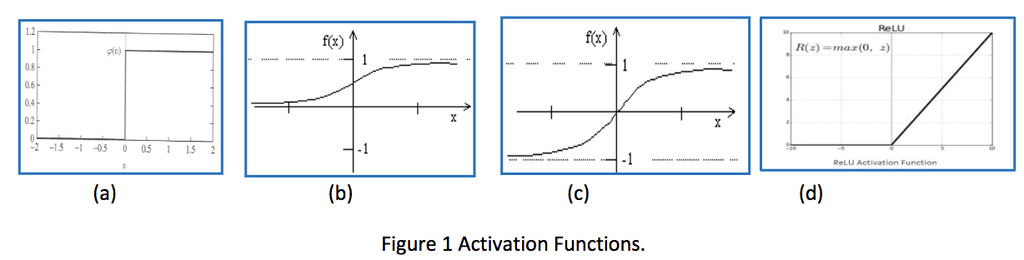

#### Figure 1 shows four activation function in the neural network, please show the mathematical formulation of each activation function [0.5], and explain the characteristics of each activation function [0.5 pt].

1. (a)Step funciton

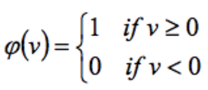

   > It is typical activation function for classification problems. If the local field(the result of summing function) reaches a threshold, the neuron output 1, otherwise the neuron output 0. It's not a continuous funciton.
1. (b)Sigmoid

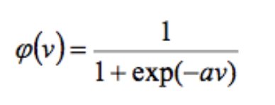

   > Sigmoid is often used for multi-layer network. It taks local field and transform it to a number between 0 and 1. It's a continuous non linear fuction differentiable everywhere.
1. (c)Hyperbolic tangent

   > Hyperbolic tangent is common used for multi-layer network as well. It take local field and transform it to a number between -1 and 1. It's a continuous non linear function differentiable everywhere. The differences between hyperbolic tangent and sigmoid is that hyperbolic tangent centered around 0 and its first derivative has larger range which gives hyperbolic function stronger gradient for learning.
1. (d)Rectified Linear Unit (ReLU)

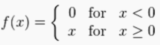

#### Question 5[1.5pts]

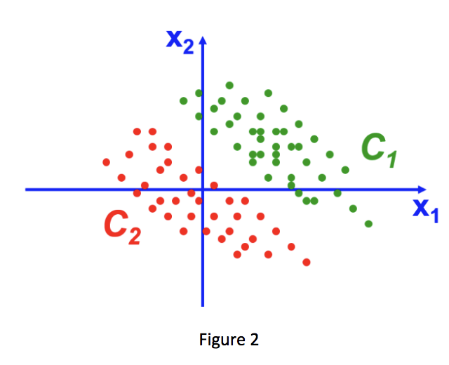

#### Figure 2 shows a set of samples (dots) which are labeled as red and green (red dots belong to class C2, and green dots belong to class C1). Explain how can we train a neuron to correctly classify dots into different classes (C1 vs. C2) [0.5 pt], What are the roles of the weight values of the neuron [0.5 pt], Show the decisionboundary of the learned neuron [0.5 pt]

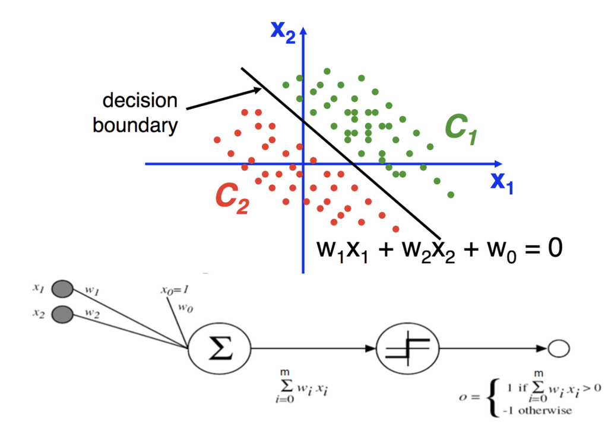

> We feed the neuron training samples with labels until the neuron adjusts its weights(w0,w1,w2)to formulate a equation that produces a decision boundry which can seperate C1 from C2. The weights determine the slope and intercepts.

#### Question 6[3pts]:

#### Please download housing.header.txt dataset from Canvas, and use a programming language (Python, R, etc.)to implement following tasks (a brief description of this dataset is available from the following URL)https://www.cs.toronto.edu/~delve/data/boston/bostonDetail.html

1. Read housing.header.txt as a dataframe. Report number of instances and features.
2. Report all samples with respect to the Crim index on a plot (the x-axis showsthe index of the sample, and the y-axis shows the crim index of the sample).
3. Show both histogram of the Crim index and the density of the Crim index on a 1x2 frame.
4. Show following four scatter plots in one frame (1x4), crim-medv, Rm-medv, Age-medv,Tax-medv, and explain how are they (Crim, Rm, Age, Tax) correlated to the medium house value(Medv)
5. Create a subset which only includes properties with Crim less than 1 (inclusive), and Rm greater than 6 (inclusive).
6. Show a scatter plot between Rm and Medv (x-axis shows Rm and y-axis denote Medv), please color all properties with 7 or larger Rm values as “red”, and rest properties as “black”.
7. Report the pairwise correlation between every two variables (either as a matrix or as a level plot)
8. Please explain which variable is mostly positively correlated to Medv (medium house value), and which variable is mostly negatively correlated to Medv.
9. Draw scatterplots to show relationship between each attributeand Medv, respectively.
10. Explainhowto use scatterplots to findattributes which are positively correlated, negatively correlated, or independent of Medv, respectively.
11. Please create a new instance with following attributevalueCrim=1.0,Zn=0.2,Indus=6,Chas=0.1,Nox=6.5,Rm=5,Age=100,Dis=4.1,Rad=4.5,Tax=21,Ptratio=20,B=300,Lstat=12,Medv=20.5include this instance into the original dataframe, and report the number of instances and features of the new dataframe.
12. Create a new feature (named“Dummy”), and include the new featureinto the new dataframe as the last feature. The valuesof the Dummy feature for each instances arerandomly generated within range [0,5].

```python
import pandas as pd
import matplotlib.pyplot as plt
import seaborn as sns
```

```python
#1. Read housing.header.txt as a dataframe. Report number of instances and features.

data = pd.read_csv('housing.header.txt')
data.head()
```

|  | Crim | Zn | Indus | Chas | Nox | Rm | Age | Dis | Rad | Tax | Ptratio | B | Lstat | Medv |
| --- | --- | --- | --- | --- | --- | --- | --- | --- | --- | --- | --- | --- | --- | --- |
| 0 | 0.00632 | 18.0 | 2.31 | 0 | 0.538 | 6.575 | 65.2 | 4.0900 | 1 | 296 | 15.3 | 396.90 | 4.98 | 24.0 |
| 1 | 0.02731 | 0.0 | 7.07 | 0 | 0.469 | 6.421 | 78.9 | 4.9671 | 2 | 242 | 17.8 | 396.90 | 9.14 | 21.6 |
| 2 | 0.02729 | 0.0 | 7.07 | 0 | 0.469 | 7.185 | 61.1 | 4.9671 | 2 | 242 | 17.8 | 392.83 | 4.03 | 34.7 |
| 3 | 0.03237 | 0.0 | 2.18 | 0 | 0.458 | 6.998 | 45.8 | 6.0622 | 3 | 222 | 18.7 | 394.63 | 2.94 | 33.4 |
| 4 | 0.06905 | 0.0 | 2.18 | 0 | 0.458 | 7.147 | 54.2 | 6.0622 | 3 | 222 | 18.7 | 396.90 | 5.33 | 36.2 |

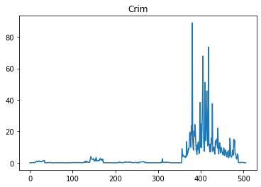

```python
#2. Report all samples with respect to the Crim index on a plot (the x-axis shows the index of the sample,
#   and the y-axis shows the crim index of the sample).
crim = data['Crim']
plt.plot(crim)
plt.title('Crim')
```

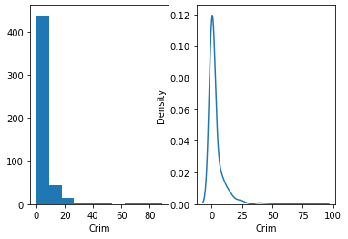

```python
#3. Show both histogram of the Crim index and the density of the Crim index on a 1x2 frame.
plt.subplot(121)
plt.hist(data['Crim'])
plt.xlabel('Crim')

plt.subplot(122)
sns.distplot(data['Crim'], hist=False, kde=True)
```

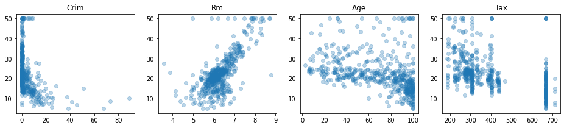

```python
#4. Show following four scatter plots in one frame (1x4), crim-medv, Rm-medv, Age-medv,Tax-medv,
#   and explain how are they (Crim, Rm, Age, Tax) correlated to the medium house value(Medv)
fields = ['Crim','Rm', 'Age', 'Tax']
medv = data['Medv']
plt.figure(figsize=(16,3))
for i,f in enumerate(fields):
    plt.subplot(1,4,i+1, title=f)
    plt.scatter(data[f], medv, alpha=0.3)
```

```python
#5.Create a subset which only includes properties with Crim less than 1 (inclusive),
#. and Rm greater than 6 (inclusive).
subset = data[(data['Crim']<=1) & (data['Rm']>=6)]
subset
```

|  | Crim | Zn | Indus | Chas | Nox | Rm | Age | Dis | Rad | Tax | Ptratio | B | Lstat | Medv |
| --- | --- | --- | --- | --- | --- | --- | --- | --- | --- | --- | --- | --- | --- | --- |
| 0 | 0.00632 | 18.0 | 2.31 | 0 | 0.538 | 6.575 | 65.2 | 4.0900 | 1 | 296 | 15.3 | 396.90 | 4.98 | 24.0 |
| 1 | 0.02731 | 0.0 | 7.07 | 0 | 0.469 | 6.421 | 78.9 | 4.9671 | 2 | 242 | 17.8 | 396.90 | 9.14 | 21.6 |
| 2 | 0.02729 | 0.0 | 7.07 | 0 | 0.469 | 7.185 | 61.1 | 4.9671 | 2 | 242 | 17.8 | 392.83 | 4.03 | 34.7 |
| 3 | 0.03237 | 0.0 | 2.18 | 0 | 0.458 | 6.998 | 45.8 | 6.0622 | 3 | 222 | 18.7 | 394.63 | 2.94 | 33.4 |
| 4 | 0.06905 | 0.0 | 2.18 | 0 | 0.458 | 7.147 | 54.2 | 6.0622 | 3 | 222 | 18.7 | 396.90 | 5.33 | 36.2 |
| ... | ... | ... | ... | ... | ... | ... | ... | ... | ... | ... | ... | ... | ... | ... |
| 501 | 0.06263 | 0.0 | 11.93 | 0 | 0.573 | 6.593 | 69.1 | 2.4786 | 1 | 273 | 21.0 | 391.99 | 9.67 | 22.4 |
| 502 | 0.04527 | 0.0 | 11.93 | 0 | 0.573 | 6.120 | 76.7 | 2.2875 | 1 | 273 | 21.0 | 396.90 | 9.08 | 20.6 |
| 503 | 0.06076 | 0.0 | 11.93 | 0 | 0.573 | 6.976 | 91.0 | 2.1675 | 1 | 273 | 21.0 | 396.90 | 5.64 | 23.9 |
| 504 | 0.10959 | 0.0 | 11.93 | 0 | 0.573 | 6.794 | 89.3 | 2.3889 | 1 | 273 | 21.0 | 393.45 | 6.48 | 22.0 |
| 505 | 0.04741 | 0.0 | 11.93 | 0 | 0.573 | 6.030 | 80.8 | 2.5050 | 1 | 273 | 21.0 | 396.90 | 7.88 | 11.9 |

236 rows × 14 columns

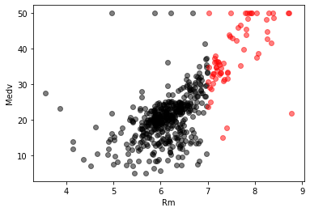

```python
#6.Show a scatter plot between Rm and Medv (x-axis shows Rm and y-axis denote Medv),
# please color all properties with 7 or larger Rm values as “red”, and rest properties as “black”.
less_than_seven = data[data['Rm']<7]
seven_and_more = data[data['Rm']>= 7]
plt.scatter(less_than_seven['Rm'], less_than_seven['Medv'],c='black', alpha=0.5)
plt.scatter(seven_and_more['Rm'], seven_and_more['Medv'],c='red', alpha=0.5)
plt.xlabel('Rm')
plt.ylabel('Medv')
plt.show()
```

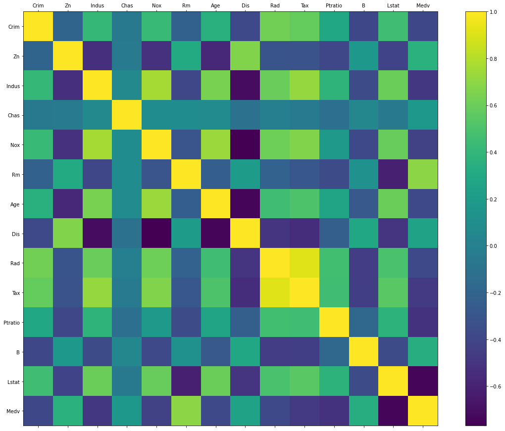

```python
#7.Report the pairwise correlation between every two variables (either as a matrix or as a level plot)
plt.figure(figsize=(20,15))
plt.matshow(data.corr(),fignum=1)
plt.xticks(range(len(data.columns)), data.columns)
plt.yticks(range(len(data.columns)), data.columns)
plt.colorbar()
plt.show()
```

#### 8.Please explain which variable is mostly positively correlated to Medv (medium house value), and which variable is mostly negatively correlated to Medv.

> Rm is mostly positively correlated to Medv while Lsta is mostly negatively correlated to Medv

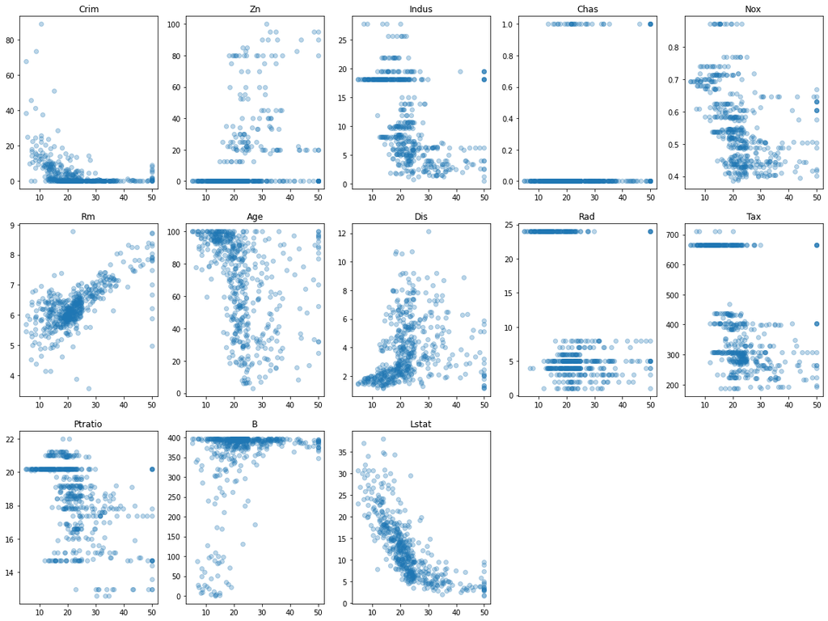

```python
#9.Draw scatterplots to show relationship between each attributeand Medv, respectively.
x = data['Medv']
plt.figure(figsize=(20,15))
for index, att in enumerate(data.columns):
    if att != 'Medv':
        plt.subplot(3,5,index+1).title.set_text(att)
        plt.scatter(x, data[att], alpha=0.3)
```

#### 10.Explain how to use scatterplots to find attributes which are positively correlated, negatively correlated, or independent of Medv, respectively.

> If two features are positively correlated, y variable increase as x variable increase. If two features are negatively correlated, y variable decrease as x variable increase. When two features are independent of each other, there is no association between two variables. In other words, dots on scatterplot appear randomly if two features are independent of each other.

```python
#11.Please create a new instance with following attribute value
#   Crim=1.0,Zn=0.2,Indus=6,Chas=0.1,Nox=6.5,Rm=5,Age=100,Dis=4.1,
#   Rad=4.5,Tax=21,Ptratio=20,B=300,Lstat=12,Medv=20.5
# include this instance into the original dataframe, and report the number of instances and features of the new dataframe.
new = {'Crim':1.0, 'Zn':0.2, 'Indus':6, 'Chas':0.1, 'Nox':6.5,
      'Rm':5, 'Age':100, 'Dis':4.1, 'Rad':4.5, 'Tax':21,
       'Ptratio':20, 'B':300, 'Lstat':12, 'Medv':20.5}

print('Shape of original data set:', data.shape)
data = data.append(new, ignore_index=True)
print('Shape of new data set:', data.shape)
data.loc[[506]]
```

```
Shape of original data set: (506, 14)
Shape of new data set: (507, 14)
```

|  | Crim | Zn | Indus | Chas | Nox | Rm | Age | Dis | Rad | Tax | Ptratio | B | Lstat | Medv |
| --- | --- | --- | --- | --- | --- | --- | --- | --- | --- | --- | --- | --- | --- | --- |
| 506 | 1.0 | 0.2 | 6.0 | 0.1 | 6.5 | 5.0 | 100.0 | 4.1 | 4.5 | 21.0 | 20.0 | 300.0 | 12.0 | 20.5 |

```python
#12.Create a new feature (named“Dummy”), and include the new featureinto the new dataframe as the last feature.
#The valuesof the Dummy feature for each instances are randomly generated within range [0,5].
from random import randint

dummy = [randint(0,5) for x in range(data.shape[0])]
data['Dummy'] = dummy
data.head()
```

|  | Crim | Zn | Indus | Chas | Nox | Rm | Age | Dis | Rad | Tax | Ptratio | B | Lstat | Medv | Dummy |
| --- | --- | --- | --- | --- | --- | --- | --- | --- | --- | --- | --- | --- | --- | --- | --- |
| 0 | 0.00632 | 18.0 | 2.31 | 0.0 | 0.538 | 6.575 | 65.2 | 4.0900 | 1.0 | 296.0 | 15.3 | 396.90 | 4.98 | 24.0 | 2 |
| 1 | 0.02731 | 0.0 | 7.07 | 0.0 | 0.469 | 6.421 | 78.9 | 4.9671 | 2.0 | 242.0 | 17.8 | 396.90 | 9.14 | 21.6 | 3 |
| 2 | 0.02729 | 0.0 | 7.07 | 0.0 | 0.469 | 7.185 | 61.1 | 4.9671 | 2.0 | 242.0 | 17.8 | 392.83 | 4.03 | 34.7 | 4 |
| 3 | 0.03237 | 0.0 | 2.18 | 0.0 | 0.458 | 6.998 | 45.8 | 6.0622 | 3.0 | 222.0 | 18.7 | 394.63 | 2.94 | 33.4 | 0 |
| 4 | 0.06905 | 0.0 | 2.18 | 0.0 | 0.458 | 7.147 | 54.2 | 6.0622 | 3.0 | 222.0 | 18.7 | 396.90 | 5.33 | 36.2 | 1 |